# Part I - Prosper Loan Data Exploration

## Introduction

Prosper loan dataset contains 113,937 loans with 81 variables on each loan, including loan amount, borrower rate (or interest rate), current loan status, borrower income, and many others.

Prosper was founded in 2005 as the first peer-to-peer lending marketplace in the United States. Since then, Prosper has facilitated more than \$22 billion in loans to more than 1,350,000 people.

Through Prosper, people can invest in each other in a way that is financially and socially rewarding. Borrowers apply online for a fixed-rate, fixed-term loan between \$2,000 and $50,000. Individuals and institutions can invest in the loans and earn attractive returns. Prosper handles all loan servicing on behalf of the matched borrowers and investors.

Prosper Marketplace is backed by leading investors including Sequoia Capital, Francisco Partners, Institutional Venture Partners, and Credit Suisse NEXT Fund. [Source:](https://www.prosper.com/about)

## Preliminary Wrangling

```python
# import all packages and set plots to be embedded inline
import numpy as np
import pandas as pd
import matplotlib.pyplot as plt
import seaborn as sb

%matplotlib inline
```

```python
df = pd.read_csv('prosperLoanData.csv')
```

```python
df.head()
```

|  | ListingKey | ListingNumber | ListingCreationDate | CreditGrade | Term | LoanStatus | ClosedDate | BorrowerAPR | BorrowerRate | LenderYield | ... | LP_ServiceFees | LP_CollectionFees | LP_GrossPrincipalLoss | LP_NetPrincipalLoss | LP_NonPrincipalRecoverypayments | PercentFunded | Recommendations | InvestmentFromFriendsCount | InvestmentFromFriendsAmount | Investors |
| --- | --- | --- | --- | --- | --- | --- | --- | --- | --- | --- | --- | --- | --- | --- | --- | --- | --- | --- | --- | --- | --- |
| 0 | 1021339766868145413AB3B | 193129 | 2007-08-26 19:09:29.263000000 | C | 36 | Completed | 2009-08-14 00:00:00 | 0.16516 | 0.1580 | 0.1380 | ... | -133.18 | 0.0 | 0.0 | 0.0 | 0.0 | 1.0 | 0 | 0 | 0.0 | 258 |
| 1 | 10273602499503308B223C1 | 1209647 | 2014-02-27 08:28:07.900000000 | NaN | 36 | Current | NaN | 0.12016 | 0.0920 | 0.0820 | ... | 0.00 | 0.0 | 0.0 | 0.0 | 0.0 | 1.0 | 0 | 0 | 0.0 | 1 |
| 2 | 0EE9337825851032864889A | 81716 | 2007-01-05 15:00:47.090000000 | HR | 36 | Completed | 2009-12-17 00:00:00 | 0.28269 | 0.2750 | 0.2400 | ... | -24.20 | 0.0 | 0.0 | 0.0 | 0.0 | 1.0 | 0 | 0 | 0.0 | 41 |
| 3 | 0EF5356002482715299901A | 658116 | 2012-10-22 11:02:35.010000000 | NaN | 36 | Current | NaN | 0.12528 | 0.0974 | 0.0874 | ... | -108.01 | 0.0 | 0.0 | 0.0 | 0.0 | 1.0 | 0 | 0 | 0.0 | 158 |
| 4 | 0F023589499656230C5E3E2 | 909464 | 2013-09-14 18:38:39.097000000 | NaN | 36 | Current | NaN | 0.24614 | 0.2085 | 0.1985 | ... | -60.27 | 0.0 | 0.0 | 0.0 | 0.0 | 1.0 | 0 | 0 | 0.0 | 20 |

5 rows × 81 columns

```python
df.shape
```

```
(113937, 81)
```

```python
df.describe()
```

|  | ListingNumber | Term | BorrowerAPR | BorrowerRate | LenderYield | EstimatedEffectiveYield | EstimatedLoss | EstimatedReturn | ProsperRating (numeric) | ProsperScore | ... | LP_ServiceFees | LP_CollectionFees | LP_GrossPrincipalLoss | LP_NetPrincipalLoss | LP_NonPrincipalRecoverypayments | PercentFunded | Recommendations | InvestmentFromFriendsCount | InvestmentFromFriendsAmount | Investors |
| --- | --- | --- | --- | --- | --- | --- | --- | --- | --- | --- | --- | --- | --- | --- | --- | --- | --- | --- | --- | --- | --- |
| count | 1.139370e+05 | 113937.000000 | 113912.000000 | 113937.000000 | 113937.000000 | 84853.000000 | 84853.000000 | 84853.000000 | 84853.000000 | 84853.000000 | ... | 113937.000000 | 113937.000000 | 113937.000000 | 113937.000000 | 113937.000000 | 113937.000000 | 113937.000000 | 113937.000000 | 113937.000000 | 113937.000000 |
| mean | 6.278857e+05 | 40.830248 | 0.218828 | 0.192764 | 0.182701 | 0.168661 | 0.080306 | 0.096068 | 4.072243 | 5.950067 | ... | -54.725641 | -14.242698 | 700.446342 | 681.420499 | 25.142686 | 0.998584 | 0.048027 | 0.023460 | 16.550751 | 80.475228 |
| std | 3.280762e+05 | 10.436212 | 0.080364 | 0.074818 | 0.074516 | 0.068467 | 0.046764 | 0.030403 | 1.673227 | 2.376501 | ... | 60.675425 | 109.232758 | 2388.513831 | 2357.167068 | 275.657937 | 0.017919 | 0.332353 | 0.232412 | 294.545422 | 103.239020 |
| min | 4.000000e+00 | 12.000000 | 0.006530 | 0.000000 | -0.010000 | -0.182700 | 0.004900 | -0.182700 | 1.000000 | 1.000000 | ... | -664.870000 | -9274.750000 | -94.200000 | -954.550000 | 0.000000 | 0.700000 | 0.000000 | 0.000000 | 0.000000 | 1.000000 |
| 25% | 4.009190e+05 | 36.000000 | 0.156290 | 0.134000 | 0.124200 | 0.115670 | 0.042400 | 0.074080 | 3.000000 | 4.000000 | ... | -73.180000 | 0.000000 | 0.000000 | 0.000000 | 0.000000 | 1.000000 | 0.000000 | 0.000000 | 0.000000 | 2.000000 |
| 50% | 6.005540e+05 | 36.000000 | 0.209760 | 0.184000 | 0.173000 | 0.161500 | 0.072400 | 0.091700 | 4.000000 | 6.000000 | ... | -34.440000 | 0.000000 | 0.000000 | 0.000000 | 0.000000 | 1.000000 | 0.000000 | 0.000000 | 0.000000 | 44.000000 |
| 75% | 8.926340e+05 | 36.000000 | 0.283810 | 0.250000 | 0.240000 | 0.224300 | 0.112000 | 0.116600 | 5.000000 | 8.000000 | ... | -13.920000 | 0.000000 | 0.000000 | 0.000000 | 0.000000 | 1.000000 | 0.000000 | 0.000000 | 0.000000 | 115.000000 |
| max | 1.255725e+06 | 60.000000 | 0.512290 | 0.497500 | 0.492500 | 0.319900 | 0.366000 | 0.283700 | 7.000000 | 11.000000 | ... | 32.060000 | 0.000000 | 25000.000000 | 25000.000000 | 21117.900000 | 1.012500 | 39.000000 | 33.000000 | 25000.000000 | 1189.000000 |

8 rows × 61 columns

```python
df.info()
```

```
<class 'pandas.core.frame.DataFrame'>
RangeIndex: 113937 entries, 0 to 113936
Data columns (total 81 columns):
ListingKey                             113937 non-null object
ListingNumber                          113937 non-null int64
ListingCreationDate                    113937 non-null object
CreditGrade                            28953 non-null object
Term                                   113937 non-null int64
LoanStatus                             113937 non-null object
ClosedDate                             55089 non-null object
BorrowerAPR                            113912 non-null float64
BorrowerRate                           113937 non-null float64
LenderYield                            113937 non-null float64
EstimatedEffectiveYield                84853 non-null float64
EstimatedLoss                          84853 non-null float64
EstimatedReturn                        84853 non-null float64
ProsperRating (numeric)                84853 non-null float64
ProsperRating (Alpha)                  84853 non-null object
ProsperScore                           84853 non-null float64
ListingCategory (numeric)              113937 non-null int64
BorrowerState                          108422 non-null object
Occupation                             110349 non-null object
EmploymentStatus                       111682 non-null object
EmploymentStatusDuration               106312 non-null float64
IsBorrowerHomeowner                    113937 non-null bool
CurrentlyInGroup                       113937 non-null bool
GroupKey                               13341 non-null object
DateCreditPulled                       113937 non-null object
CreditScoreRangeLower                  113346 non-null float64
CreditScoreRangeUpper                  113346 non-null float64
FirstRecordedCreditLine                113240 non-null object
CurrentCreditLines                     106333 non-null float64
OpenCreditLines                        106333 non-null float64
TotalCreditLinespast7years             113240 non-null float64
OpenRevolvingAccounts                  113937 non-null int64
OpenRevolvingMonthlyPayment            113937 non-null float64
InquiriesLast6Months                   113240 non-null float64
TotalInquiries                         112778 non-null float64
CurrentDelinquencies                   113240 non-null float64
AmountDelinquent                       106315 non-null float64
```

[output cut: 31 more lines]

```
LP_CustomerPayments                    113937 non-null float64
LP_CustomerPrincipalPayments           113937 non-null float64
LP_InterestandFees                     113937 non-null float64
LP_ServiceFees                         113937 non-null float64
LP_CollectionFees                      113937 non-null float64
LP_GrossPrincipalLoss                  113937 non-null float64
LP_NetPrincipalLoss                    113937 non-null float64
LP_NonPrincipalRecoverypayments        113937 non-null float64
PercentFunded                          113937 non-null float64
Recommendations                        113937 non-null int64
InvestmentFromFriendsCount             113937 non-null int64
InvestmentFromFriendsAmount            113937 non-null float64
Investors                              113937 non-null int64
dtypes: bool(3), float64(50), int64(11), object(17)
memory usage: 68.1+ MB
```

```python
list(df['ListingCategory (numeric)'].sort_values().unique())
```

```
[0, 1, 2, 3, 4, 5, 6, 7, 8, 9, 10, 11, 12, 13, 14, 15, 16, 17, 18, 19, 20]
```

```python
# Create a copy of the original dataset before wrangling

df_clean = df.copy()
```

```python
columns_of_interest =  ['LoanKey', 'Term','ClosedDate', 'EmploymentStatus', 'Occupation', 'Recommendations', 'LoanStatus', 'BorrowerRate', 'ProsperRating (numeric)',
     'StatedMonthlyIncome', 'TotalProsperLoans', 'LoanOriginalAmount', 'ListingCategory (numeric)',
    'LoanOriginationDate','DelinquenciesLast7Years', 'Investors']
```

```python
df_clean = df_clean[columns_of_interest]
```

```python
# Dtype conversion for categorical variables

def change_type(dataFrame, columns = [], dType = 'Str'):
    for col in columns:
        dataFrame[col] = dataFrame[col].astype(dType)

ListingCategory_mapping = {0:'Not Available', 1:'Debt Consolidation', 2:'Home Improvement', 3:'Business', 4:'Personal Loan', 5:'Student Use', 6:'Auto', 7:'Other', 8:'Baby&Adoption', 9:'Boat', 10:'Cosmetic Procedure', 11:'Engagement Ring', 12:'Green Loans', 13:'Household Expenses', 14:'Large Purchases', 15:'Medical/Dental', 16:'Motorcycle', 17:'RV', 18:'Taxes', 19:'Vacation', 20:'Wedding Loans'}

# Convert ProsperRating (numeric) into an ordered categorical type
ordered_var = pd.api.types.CategoricalDtype(ordered = True, categories = [0,1,2,3,4,5,6,7])
df_clean['ProsperRating (numeric)'] = df_clean['ProsperRating (numeric)'].astype(ordered_var)

# Convert ListingCategory (numeric) into comprehensible text
df_clean['ListingCategory (numeric)'] = df_clean['ListingCategory (numeric)'].apply(lambda x: ListingCategory_mapping[x])
```

```python
# Convert Term, EmploymentStatus, LoanStatus, ListingCategory (numeric) to nominal categories

nom_cat_columns = ['Term', 'EmploymentStatus', 'Occupation', 'LoanStatus', 'ListingCategory (numeric)']

change_type(df_clean, columns = nom_cat_columns, dType = 'category')
```

```python
df_clean.duplicated().sum()
```

```
871
```

```python
df_clean[df_clean.LoanKey.duplicated() == True]['LoanKey'].tail(8)
```

```
113386    2B563706560837952804BF1
113431    EE393703717196793CEB4D5
113468    84F13693686671206E56CF0
113548    6C203707183544065E3E202
113636    F3E73698701527272D54247
113733    F3AB369770667777597274C
113773    D895370150591392337ED6D
113863    7D6A3699075363390CD7242
Name: LoanKey, dtype: object
```

- LoanKey is meant to be unique.

```python
df_clean.query("LoanKey == '6C203707183544065E3E202'")
```

|  | LoanKey | Term | ClosedDate | EmploymentStatus | Occupation | Recommendations | LoanStatus | BorrowerRate | ProsperRating (numeric) | StatedMonthlyIncome | TotalProsperLoans | LoanOriginalAmount | ListingCategory (numeric) | LoanOriginationDate | DelinquenciesLast7Years | Investors |
| --- | --- | --- | --- | --- | --- | --- | --- | --- | --- | --- | --- | --- | --- | --- | --- | --- |
| 92814 | 6C203707183544065E3E202 | 60 | NaN | Employed | Other | 0 | Current | 0.196 | 3 | 7666.666667 | NaN | 14000 | Taxes | 2014-03-04 00:00:00 | 0.0 | 1 |
| 113548 | 6C203707183544065E3E202 | 60 | NaN | Employed | Other | 0 | Current | 0.196 | 3 | 7666.666667 | NaN | 14000 | Taxes | 2014-03-04 00:00:00 | 0.0 | 1 |

```python
df_clean.query("LoanKey == 'F3E73698701527272D54247'")
```

|  | LoanKey | Term | ClosedDate | EmploymentStatus | Occupation | Recommendations | LoanStatus | BorrowerRate | ProsperRating (numeric) | StatedMonthlyIncome | TotalProsperLoans | LoanOriginalAmount | ListingCategory (numeric) | LoanOriginationDate | DelinquenciesLast7Years | Investors |
| --- | --- | --- | --- | --- | --- | --- | --- | --- | --- | --- | --- | --- | --- | --- | --- | --- |
| 37400 | F3E73698701527272D54247 | 36 | NaN | Other | NaN | 0 | Current | 0.176 | 4 | 2500.0 | NaN | 4000 | Debt Consolidation | 2013-11-12 00:00:00 | 11.0 | 1 |
| 113636 | F3E73698701527272D54247 | 36 | NaN | Other | NaN | 0 | Current | 0.176 | 4 | 2500.0 | NaN | 4000 | Debt Consolidation | 2013-11-12 00:00:00 | 11.0 | 1 |

```python
df_clean.query("LoanKey == '84F13693686671206E56CF0'")
```

|  | LoanKey | Term | ClosedDate | EmploymentStatus | Occupation | Recommendations | LoanStatus | BorrowerRate | ProsperRating (numeric) | StatedMonthlyIncome | TotalProsperLoans | LoanOriginalAmount | ListingCategory (numeric) | LoanOriginationDate | DelinquenciesLast7Years | Investors |
| --- | --- | --- | --- | --- | --- | --- | --- | --- | --- | --- | --- | --- | --- | --- | --- | --- |
| 77827 | 84F13693686671206E56CF0 | 60 | NaN | Employed | Tradesman - Mechanic | 0 | Current | 0.2015 | 4 | 3333.333333 | NaN | 5000 | Debt Consolidation | 2013-10-02 00:00:00 | 0.0 | 1 |
| 113468 | 84F13693686671206E56CF0 | 60 | NaN | Employed | Tradesman - Mechanic | 0 | Current | 0.2015 | 4 | 3333.333333 | NaN | 5000 | Debt Consolidation | 2013-10-02 00:00:00 | 0.0 | 1 |

```python
# drop duplicate rows
df_clean.drop_duplicates(inplace=True)
```

```python
# Test for duplicates

df_clean[df_clean.LoanKey.duplicated() == True].sum()
```

```
LoanKey                      0.0
Term                         0.0
ClosedDate                   0.0
EmploymentStatus             0.0
Occupation                   0.0
Recommendations              0.0
LoanStatus                   0.0
BorrowerRate                 0.0
ProsperRating (numeric)      0.0
StatedMonthlyIncome          0.0
TotalProsperLoans            0.0
LoanOriginalAmount           0.0
ListingCategory (numeric)    0.0
LoanOriginationDate          0.0
DelinquenciesLast7Years      0.0
Investors                    0.0
dtype: float64
```

```python
# Check for NAN

df_clean.isna().sum()
```

```
LoanKey                          0
Term                             0
ClosedDate                   57990
EmploymentStatus              2255
Occupation                    3529
Recommendations                  0
LoanStatus                       0
BorrowerRate                     0
ProsperRating (numeric)      29084
StatedMonthlyIncome              0
TotalProsperLoans            91143
LoanOriginalAmount               0
ListingCategory (numeric)        0
LoanOriginationDate              0
DelinquenciesLast7Years        990
Investors                        0
dtype: int64
```

- ProsperRating (numeric) has a lot of missing values
- TotalProsperLoans has a lot of missing values
- ClosedDate has a lot of missing values but this is understandable for loans that are not closed

```python
# Drop the blanks in ProsperRating (numeric)

df_clean = df_clean.dropna(subset=['ProsperRating (numeric)']).reset_index()
```

```python
# Fill the blanks in TotalProsperLoans with the mean

mean_TotalProsperLoans = round(df_clean.TotalProsperLoans.mean())

df_clean.Occupation = df_clean.Occupation.fillna('Other')
df_clean.TotalProsperLoans = df_clean.TotalProsperLoans.fillna(mean_TotalProsperLoans)
```

```python
# Check for NAN
df_clean.isna().sum()
```

```
index                            0
LoanKey                          0
Term                             0
ClosedDate                   57990
EmploymentStatus                 0
Occupation                       0
Recommendations                  0
LoanStatus                       0
BorrowerRate                     0
ProsperRating (numeric)          0
StatedMonthlyIncome              0
TotalProsperLoans                0
LoanOriginalAmount               0
ListingCategory (numeric)        0
LoanOriginationDate              0
DelinquenciesLast7Years          0
Investors                        0
dtype: int64
```

```python
# Convert TotalProsperLoans, LoanOriginalAmount, DelinquenciesLast7Years to int

nom_cat_columns = ['TotalProsperLoans', 'LoanOriginalAmount', 'DelinquenciesLast7Years']

change_type(df_clean, columns = nom_cat_columns, dType = 'int')
```

```python
df_clean.LoanOriginationDate = pd.to_datetime(df_clean.LoanOriginationDate, format='%Y-%m-%d %H:%M:%S.%f')
```

```python
df_clean.ClosedDate = pd.to_datetime(df_clean.ClosedDate, format='%Y-%m-%d %H:%M:%S.%f')
```

```python
df_clean = df_clean.rename(columns = {'ListingCategory (numeric)' : 'ListingCategory'})
```

```python
df_clean.info()
```

```
<class 'pandas.core.frame.DataFrame'>
RangeIndex: 83982 entries, 0 to 83981
Data columns (total 17 columns):
index                      83982 non-null int64
LoanKey                    83982 non-null object
Term                       83982 non-null category
ClosedDate                 25992 non-null datetime64[ns]
EmploymentStatus           83982 non-null category
Occupation                 83982 non-null category
Recommendations            83982 non-null int64
LoanStatus                 83982 non-null category
BorrowerRate               83982 non-null float64
ProsperRating (numeric)    83982 non-null category
StatedMonthlyIncome        83982 non-null float64
TotalProsperLoans          83982 non-null int64
LoanOriginalAmount         83982 non-null int64
ListingCategory            83982 non-null category
LoanOriginationDate        83982 non-null datetime64[ns]
DelinquenciesLast7Years    83982 non-null int64
Investors                  83982 non-null int64
dtypes: category(6), datetime64[ns](2), float64(2), int64(6), object(1)
memory usage: 7.5+ MB
```

### What is the structure of your dataset?

There are 113937 loan records in the original dataset with 81 features. Most variables are numeric in nature, but the variable ProsperRating (numeric) is an ordered factor variable with the following levels:

(worst) ——> (best)  
ProsperRating (numeric) : 0,1,2,3,4,5,6,7

Term, EmploymentStatus, LoanStatus, ListingCategory (numeric) are nominal categoricals

### What is/are the main feature(s) of interest in your dataset?

- Popular loans (amount and categories)
- How investors choose to finance loans
- Accuracy of borrower profiling

### What features in the dataset do you think will help support your investigation into your feature(s) of interest?

- Loan amount
- Borrower rating
- Investors
- Borrower income

## Univariate Exploration

I'll start by looking at the distribution of the main variable of interest: LoanOriginalAmount.

### LOAN ORIGINAL AMOUNT

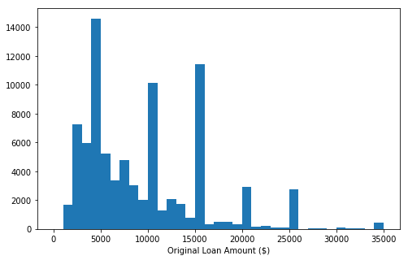

```python
# start with a standard-scaled plot

default_color = sb.color_palette()[0]

binsize = 1000
bins = np.arange(0, df_clean['LoanOriginalAmount'].max()+binsize, binsize)

plt.figure(figsize=[8, 5])
plt.hist(data = df_clean, x = 'LoanOriginalAmount', bins = bins)
plt.xlabel('Original Loan Amount ($)')
plt.show();
```

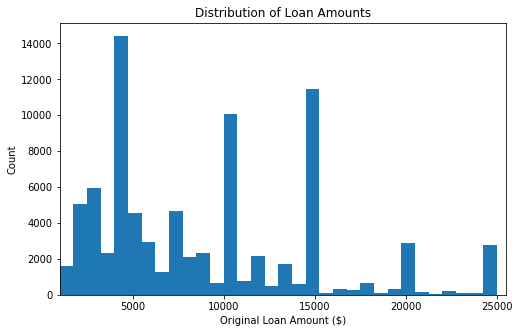

```python
# investigating further on an even smaller bin size
binsize = 500
bins = np.arange(1000, 25500,750)

plt.figure(figsize=[8, 5])
plt.hist(data = df_clean, x = 'LoanOriginalAmount', bins = bins)
plt.title('Distribution of Loan Amounts')
plt.xlim([1000,25500])
plt.xlabel('Original Loan Amount ($)')
plt.ylabel('Count')
plt.show();
```

The smaller bin size confirms the pattern seen previously for the distribution of Loan Amount. We can see spikes in the frequency of loans that are multiples of \$5,0000; frequency then trails off until the next spike. These probably represent popular amounts with which making calculations and budgeting are easy.

I'll now move on to what people borrow money for.

### LISTING CATEGORIES

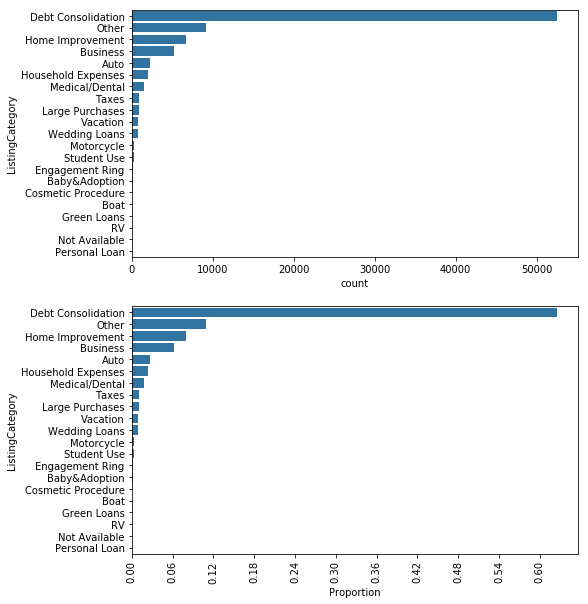

```python
# Let's see how each category fares

fig, ax = plt.subplots(nrows=2, figsize = [8,10])

# get order of bars by frequency
category_counts = df_clean['ListingCategory'].value_counts()
category_order = category_counts.index

# Compute largest proportion
n_category = df_clean['ListingCategory'].value_counts().sum()
max_category_count = category_counts.values[0]
max_prop = max_category_count / n_category

# establish tick locations and create plot
tick_props = np.arange(0, max_prop, 0.06)
tick_names = ['{:0.2f}'.format(v) for v in tick_props]

sb.countplot(data = df_clean, y = 'ListingCategory', color = default_color, order = category_order, ax = ax[0])
plt.xticks(rotation = 90);

sb.countplot(data = df_clean, y = 'ListingCategory', color = default_color, order = category_order, ax = ax[1])
plt.xticks(tick_props * n_category, tick_names)
plt.xlabel('Proportion')
plt.xticks(rotation = 90);
```

```python
df_clean['ListingCategory'].value_counts().values[1:].sum()
```

```
31486
```

Debt consolidation is clearly the highest type of loan taken. It accounts for more than all the other loans combined in frequency. This makes sense as people take a debt consolidation to mop up all their existing loans with more favorable payment plans and periods.

Next, I will examine how loans were accessed over time. Are more and more loans taken over time?

### LOAN ORIGINATION DATE

```python
# A quick summary of the dates loans were taken

df_clean.LoanOriginationDate.describe()
```

```
count                   83982
unique                   1165
top       2013-11-13 00:00:00
freq                      469
first     2009-07-20 00:00:00
last      2014-03-12 00:00:00
Name: LoanOriginationDate, dtype: object
```

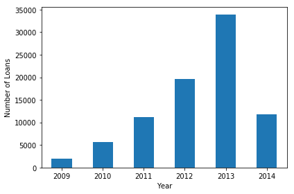

```python
# Loan counts by year

df_clean.groupby(df_clean.LoanOriginationDate.dt.year).count()['LoanOriginationDate'].plot(kind='bar', color = default_color)
plt.xlabel('Year')
plt.ylabel('Number of Loans')
plt.xticks(rotation=0)
plt.tight_layout();
```

Why does the first records start in 2009? Prosper was founded in 2005. Is it possible a subset of the data was removed during our preliminary wrangling operations? Let us take a look at the same plot but with the original dataset.

```python
df.LoanOriginationDate = pd.to_datetime(df.LoanOriginationDate, format='%Y-%m-%d %H:%M:%S.%f')
```

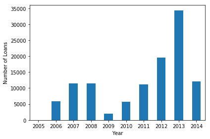

```python
# Loan counts by year

df.groupby(df.LoanOriginationDate.dt.year).count()['LoanOriginationDate'].plot(kind='bar', color = default_color)
plt.xlabel('Year')
plt.ylabel('Number of Loans')
plt.xticks(rotation=0)
plt.tight_layout();
```

Although Prosper started business in 2005, they had to cease operations between Nov 2008 - July 2009 due to a cease order by SEC. This accounts for the steep drop in loans given between 2008 and 2009. [Read More:](https://en.wikipedia.org/wiki/Prosper_Marketplace#Cease_and_desist_order)

Since 2009, the number of new loans increases steadily, with a record number of new loans in 2013. There are only two months of full data for 2014. This accounts for the low count which may be wrongly interpreted as the outcome of another major issue that affected the business.

### LOAN STATUS

```python
# Quick overview of the loan status

df_clean.LoanStatus.value_counts()
```

```
Current                   55730
Completed                 19651
Chargedoff                 5336
Defaulted                  1005
Past Due (1-15 days)        800
Past Due (31-60 days)       361
Past Due (61-90 days)       311
Past Due (91-120 days)      304
Past Due (16-30 days)       265
FinalPaymentInProgress      203
Past Due (>120 days)         16
Cancelled                     0
Name: LoanStatus, dtype: int64
```

We can see from this that the loans fall into two main groups as regards their status: Current loans and Completed loans.  
We will explore this two categories in this section.

```python
# Create a feature to indicate if a loan is active or not

completedStatus = ['Completed','Chargedoff','Cancelled','Defaulted']

df_clean['LoanStatusActive'] = df_clean['LoanStatus'].apply(lambda x: 0 if x in completedStatus else 1)

df_clean.LoanStatusActive = df_clean['LoanStatusActive'].astype('bool')

df_clean.LoanStatusActive.value_counts()
```

```
True     57990
False    25992
Name: LoanStatusActive, dtype: int64
```

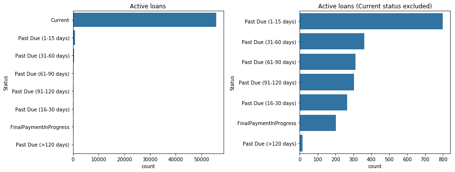

```python
# Active Loans

plt.figure(figsize=(13,5))
plt.subplot(1,2,1)

order = [x for x in df_clean[df_clean.LoanStatusActive == 1]['LoanStatus'].value_counts().index if x not in completedStatus]

sb.countplot(data = df_clean.query('LoanStatusActive == 1'),order=order, y = 'LoanStatus', color = default_color, orient = 'h')
# plt.xticks(rotation = 0)
plt.ylabel('Status')
plt.title('Active loans')

plt.subplot(1,2,2)

order = [x for x in df_clean[df_clean.LoanStatusActive == 1]['LoanStatus'].value_counts().index if x not in completedStatus and x != "Current"]

sb.countplot(data = df_clean.query('LoanStatus == @order'), y = 'LoanStatus', order = order, color = default_color, orient = 'h')
plt.xticks(rotation = 0)
plt.title('Active loans (Current status excluded)')
plt.ylabel('Status')
plt.tight_layout();
```

Current Loans make up for over 96% of active loans.  
Past Due (1-15 days) is the modal class for active, non-current loans

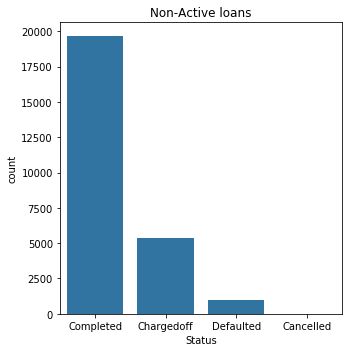

```python
# Not Active Loans

plt.figure(figsize=(5,5))

order = [x for x in df_clean[df_clean.LoanStatusActive == 0]['LoanStatus'].value_counts().index if x in completedStatus]

sb.countplot(data = df_clean.query('LoanStatusActive == 0'),order=order, x = 'LoanStatus', color = default_color)
# plt.xticks(rotation = 0)
plt.title('Non-Active loans')
plt.xlabel('Status')
plt.tight_layout();
```

### Discuss the distribution(s) of your variable(s) of interest. Were there any unusual points? Did you need to perform any transformations?

Loans that are close multiples of $5000 are very popular. Using smaller bin sizes, I had to zoom in on the initial plot to confirm this.

### Of the features you investigated, were there any unusual distributions? Did you perform any operations on the data to tidy, adjust, or change the form of the data? If so, why did you do this?

The number of loans given over time is bimodal and this is a result of a lawsuit that caused Prosper to cease operations between Nov 2008 - July 2009.

## Bivariate Exploration

I will begin this section by looking at the pairwise correlations present between features in the data.

```python
df_clean.ListingCategory.value_counts()
```

```
Debt Consolidation    52496
Other                  9172
Home Improvement       6756
Business               5266
Auto                   2233
Household Expenses     1987
Medical/Dental         1507
Taxes                   882
Large Purchases         863
Vacation                764
Wedding Loans           762
Motorcycle              304
Student Use             274
Engagement Ring         214
Baby&Adoption           196
Cosmetic Procedure       91
Boat                     85
Green Loans              58
RV                       52
Not Available            20
Personal Loan             0
Name: ListingCategory, dtype: int64
```

```python
numeric_vars = [x for x in list(df_clean) if df_clean[x].dtype in ('int64','float') and x != 'index']

# print(f'Numeric Variables are: {numeric_vars}\n')

categoric_vars = ['EmploymentStatus', 'Occupation', 'LoanStatus', 'ProsperRating (numeric)']
```

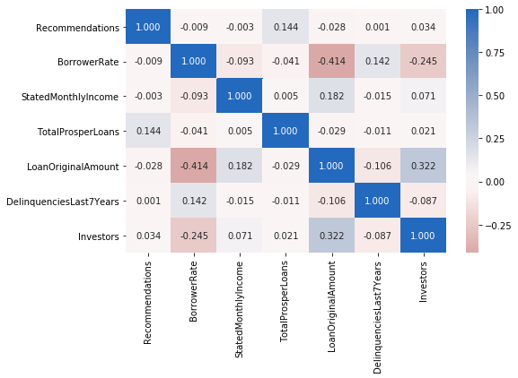

```python
# correlation plot
plt.figure(figsize = [8, 5])
sb.heatmap(df_clean[numeric_vars].corr(), annot = True, fmt = '.3f',
           cmap = 'vlag_r', center = 0)
plt.show();
```

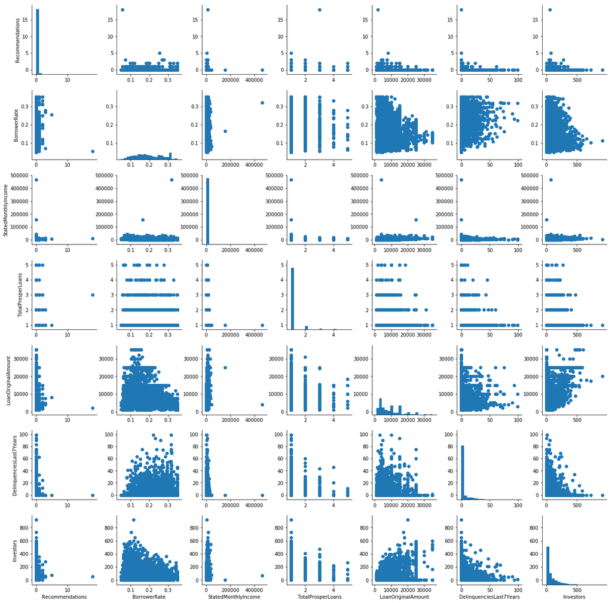

```python
# plot matrix: sample 5000 loans so that plots are clearer and they render faster

df_clean_samp = df_clean.sample(n=5000, replace = False)

g = sb.PairGrid(data = df_clean_samp, vars = numeric_vars)
g = g.map_diag(plt.hist, bins = 20);
g.map_offdiag(plt.scatter);
```

### Listing category vs. Loan status

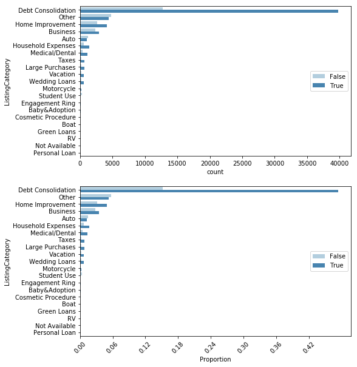

```python
fig, ax = plt.subplots(nrows=2, figsize = [8,10])

# get order of bars by frequency
category_counts = df_clean.groupby('LoanStatusActive').ListingCategory.value_counts()

# Compute largest proportion
# n_category = df_clean['ListingCategory'].value_counts().sum()
max_category_count = category_counts.values.max()
max_prop = max_category_count / n_category

# establish tick locations and create plot
tick_props = np.arange(0, max_prop, 0.06)
tick_names = ['{:0.2f}'.format(v) for v in tick_props]

sb.countplot(data = df_clean, y = 'ListingCategory', hue = 'LoanStatusActive', palette = 'Blues',
             order = category_order, ax = ax[0])
plt.xticks(rotation = 45)
ax[0].legend(loc='right');

sb.countplot(data = df_clean, y = 'ListingCategory', hue = 'LoanStatusActive', palette = 'Blues',
             order = category_order, ax = ax[1])
plt.xticks(tick_props * n_category, tick_names)
plt.xlabel('Proportion')
plt.xticks(rotation = 45)
ax[1].legend(loc='right');
```

### Pairs of Employment status, Loan status, and Prosper rating

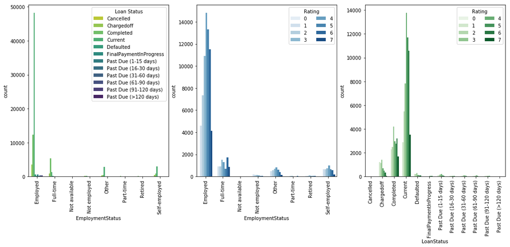

```python
# plotting with the full data should be fine now because we are looking at only three categories.
plt.figure(figsize = [18, 6.667])


# subplot 1: EmploymentStatus vs LoanStatus
plt.subplot(1, 3, 1)
sb.countplot(data = df_clean, x = 'EmploymentStatus', hue = 'LoanStatus', palette = 'viridis_r')
plt.legend(ncol = 1,loc=1,title='Loan Status')
plt.xticks(rotation=90)

# subplot 2: EmploymentStatus vs. ProsperRating (numeric)
ax = plt.subplot(1, 3, 2)
sb.countplot(data = df_clean, x = 'EmploymentStatus', hue = 'ProsperRating (numeric)', palette = 'Blues')
ax.legend(ncol = 2,title='Rating')
plt.xticks(rotation=90)

# subplot 3: LoanStatus vs. ProsperRating (numeric)
ax = plt.subplot(1, 3, 3)
sb.countplot(data = df_clean, x = 'LoanStatus', hue = 'ProsperRating (numeric)', palette = 'Greens')
ax.legend(loc = 1, ncol = 2,title='Rating')
plt.xticks(rotation=90)

plt.show();
```

Having done the preliminary look at bivariate relationships, I will to drill down some of the relationships more.  
First, I want to see how loan amount and number of investors are related to one another for all of the data.

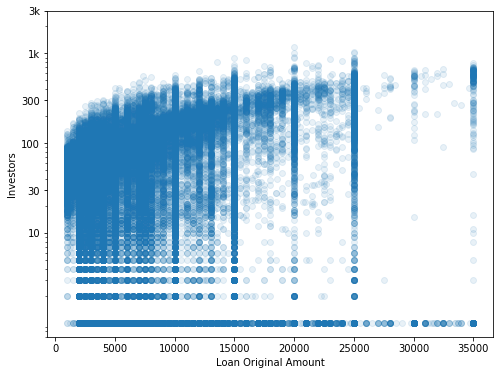

```python
# scatter plot of loan amount vs. investors, with log transform on price axis

plt.figure(figsize = [8, 6])
plt.scatter(data = df_clean, x = 'LoanOriginalAmount', y = 'Investors', alpha = 1/10)
# plt.xlim([0, 3.5])
plt.xlabel('Loan Original Amount')
plt.yscale('log')
plt.yticks([10, 30, 100, 300, 1e3, 3e3], [10, 30, 100, 300, '1k', '3k'])
plt.ylabel('Investors')
plt.show();
```

Now, let's take a second look at the loan amount and investors distributions on the three categorical variables: employment status, loan status, and rating.

```python
# compute the logarithm of loan amount to make multivariate plotting easier

def log_trans(x, inverse = False):
    """ quick function for computing log and power operations """
    if not inverse:
        return np.log10(x)
    else:
        return np.power(10, x)


def cuberoot_trans(x, inverse = False):
    """ quick function for computing cube root and cube operations """
    if not inverse:
        return x ** (1/3)
    else:
        return x ** 3

df_clean['log_LoanOriginalAmount'] = df_clean['LoanOriginalAmount'].apply(log_trans)
df_clean['cr_TotalProsperLoans'] = df_clean['TotalProsperLoans'].apply(cuberoot_trans)
```

[figure not shown]

```python
# plot the categorical variables against loan amoun and investors again, this time
# with full data and variable transforms

fig, ax = plt.subplots(ncols = 2, nrows = 4 , figsize = [25,25])
investor_ticks = [0.2, 0.3, 0.5, 0.7, 1, 1.5, 2, 3,3.2]

for i in range(len(categoric_vars)):
    var = categoric_vars[i]
    sb.violinplot(data = df_clean, x = var, y = 'log_LoanOriginalAmount', ax = ax[i,0],
               color = default_color)

    ax[i,0].set_yticks(log_trans(np.array([500, 1e3, 2e3, 5e3, 1e4, 2e4,5e4])))
    ax[i,0].set_yticklabels([500, '1k', '2k','5k','10k','20k','50k'])
    if var in ('EmploymentStatus', 'LoanStatus','Occupation'):
        ax[i,0].set_xticklabels(labels=df_clean[var].value_counts().index,rotation=90)

    sb.violinplot(data = df_clean, x = var, y = 'Investors', ax = ax[i,1],
               color = default_color)
    if var in ('EmploymentStatus', 'LoanStatus','Occupation'):
        ax[i,1].set_xticklabels(labels=df_clean[var].value_counts().index,rotation=90)

plt.show();
```

### Talk about some of the relationships you observed in this part of the investigation. How did the feature(s) of interest vary with other features in the dataset?

- Loan amount offered has a significant correlation with the number of investors
- Loan amount also increases with higher prosper ratings

## Multivariate Exploration

```python
def hist2dgrid(x, y, **kwargs):
    """ Quick hack for creating heat maps with seaborn's PairGrid. """
    palette = kwargs.pop('color')
    rotation = kwargs.pop('rotation')
    bins_x = np.arange(cuberoot_trans(0.2), cuberoot_trans(4)+.07, .07)
    bins_y = np.arange(2.68, 4.7+0.2, 0.2)
    plt.hist2d(x, y, bins = [bins_x, bins_y], cmap = palette, cmin = 0.5)
    plt.xticks(cuberoot_trans(np.array(investor_ticks)), investor_ticks, rotation = rotation)
    plt.yticks(log_trans(np.array([500, 1e3, 2e3, 5e3, 1e4, 2e4,5e4])),
               [500, '1k', '2k','5k','10k','20k','50k'])
```

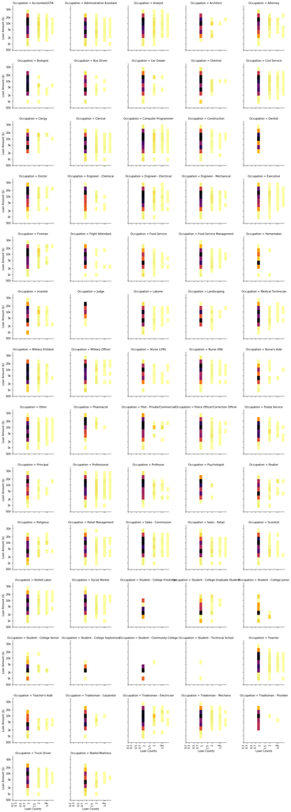

```python
# create faceted heat maps on levels of the cut variable
g = sb.FacetGrid(data = df_clean, col = 'Occupation', col_wrap = 5, size = 3) #xlim = [cuberoot_trans(.18), cuberoot_trans(3.5)
g.map(hist2dgrid, 'cr_TotalProsperLoans', 'log_LoanOriginalAmount', color = 'inferno_r', rotation = 90)
g.set_xlabels('Loan Counts')
g.set_ylabels('Loan Amount ($)')

plt.show();
```

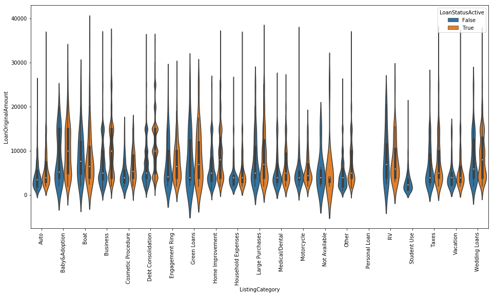

```python
plt.figure(figsize = [16, 8])
sb.violinplot(data=df_clean, x='ListingCategory', y='LoanOriginalAmount', hue='LoanStatusActive')
plt.xticks(rotation=90);
```

- Debt Consolidation, Business and Home Improvement categories have some interesting clusters around the quartile ranges

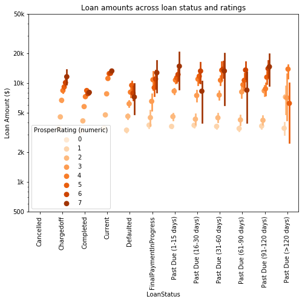

```python
fig = plt.figure(figsize = [8,6])
ax = sb.pointplot(data = df_clean, x = 'LoanStatus', y = 'LoanOriginalAmount', hue = 'ProsperRating (numeric)',
           palette = 'Oranges', linestyles = '', dodge = 0.4)
plt.title('Loan amounts across loan status and ratings')
plt.ylabel('Loan Amount ($)')
plt.yscale('log')
plt.yticks([500, 1e3, 2e3, 5e3, 1e4, 2e4,5e4], [500, '1k', '2k','5k','10k','20k','50k'])
ax.set_yticklabels([],minor = True)
plt.xticks(rotation = 90)
plt.show();
```

The hierarchy in rating by loan amount is clear when clustered across loan status values. The pattern looks quite systematic.

### Were there any interesting or surprising interactions between features?

Borrowers with the highest rating (7) still default on their loans. Although good ratings give access to better loans, they are not a guarantee for the investors on the safety of the returns on investments.